# Group1_EDA_Event_and_Subjects_for_Data_Preparing

## Group 1: Final Project - EDA and Data Prepare

### Sihe Zheng, szheng12@depaul.edu

### YunTzu Yu, yyu54@depaul.edu

### Saruul Enkhtur, senkhtur@depaul.edu

### Lukasz Grzybek, lgrzybek@depaul.edu

#### DePaul University, College of Computing and Digital Media,

#### DSC 672 DATA SCIENCE CAPSTONE

## Import Package For this project

```python
from google.colab import drive
drive.mount("/content/drive")
```

```python
import pandas as pd
import numpy as np
import matplotlib.pyplot as plt
import seaborn as sns
import os
import tqdm
import glob
```

## Load and Read Dataset

Working the project with google colab:

Train:

Defog path: /content/drive/MyDrive/DSC672/data/train/defog

Tdcsfog path: /content/drive/MyDrive/DSC672/data/train/tdcsfog

Test:

Defog path: /content/drive/MyDrive/DSC672/data/test/defog

Tdcsfog path: /content/drive/MyDrive/DSC672/data/test/tdcsfog

```python
data_dir='/content/drive/MyDrive/DSC672/data/'
daily_metadata_file = f'{data_dir}daily_metadata.csv'
defog_metadata_file = f'{data_dir}defog_metadata.csv'
tdcsfog_metadata_file = f'{data_dir}tdcsfog_metadata.csv'
events_data_file = f'{data_dir}events.csv'
subjects_data_file = f'{data_dir}subjects.csv'
tasks_data_file = f'{data_dir}tasks.csv'

# Read the meta data
daily_metadata = pd.read_csv(daily_metadata_file)
defog_metadata = pd.read_csv(defog_metadata_file)
tdcsfog_metadata = pd.read_csv(tdcsfog_metadata_file)

events_data = pd.read_csv(events_data_file)
subjects_data = pd.read_csv(subjects_data_file)
tasks_data = pd.read_csv(tasks_data_file)
```

## Events Data

```python
events_data.head()
```

|  | Id | Init | Completion | Type | Kinetic |
| --- | --- | --- | --- | --- | --- |
| 0 | 003f117e14 | 8.61312 | 14.7731 | Turn | 1.0 |
| 1 | 009ee11563 | 11.38470 | 41.1847 | Turn | 1.0 |
| 2 | 009ee11563 | 54.66470 | 58.7847 | Turn | 1.0 |
| 3 | 011322847a | 28.09660 | 30.2966 | Turn | 1.0 |
| 4 | 01d0fe7266 | 30.31840 | 31.8784 | Turn | 1.0 |

```python
# Check for missing values in the subjects_data dataframe
print(events_data.isnull().sum())
```

```
Id               0
Init             0
Completion       0
Type          1042
Kinetic       1042
dtype: int64
```

```
Turn               1997
Walking             398
StartHesitation     107
Name: Type, dtype: int64
```

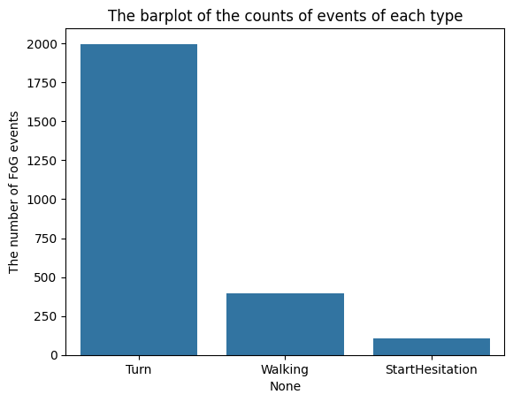

```python
print(events_data.Type.value_counts())
# create a barplot of the counts of events of each type
sns.barplot(x=events_data.Type.value_counts().index,
            y=events_data.Type.value_counts())
plt.title('The barplot of the counts of events of each type')
plt.ylabel('The number of FoG events')
plt.show()
```

The number of FoG events of Turn type is higher than other types.

```
1.0    2046
0.0     456
Name: Kinetic, dtype: int64
```

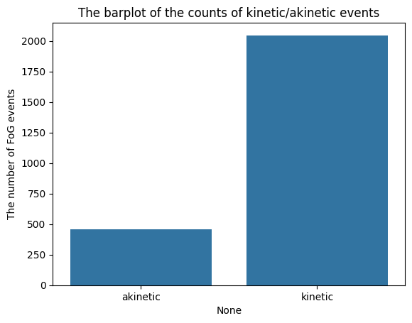

```python
print(events_data.Kinetic.value_counts())
# create a barplot of the counts of kinetic/akinetic events
fig, ax = plt.subplots()
sns.barplot(x=events_data.Kinetic.value_counts().index,
            y=events_data.Kinetic.value_counts())
plt.title('The barplot of the counts of kinetic/akinetic events')
plt.ylabel('The number of FoG events')
ax.set_xticklabels(['akinetic', 'kinetic'])
plt.show()
```

Most of the events in the dataset are kinetic.

Calculate the duration of each FoG event by subtracting the Init column (Time (s) the event began) from the Completion (Time (s) the event ended).

```python
events_data['event_duration'] = events_data['Completion'] - events_data['Init']
```

#### Distribution of FOG event duration for each type of event

As we've seen, there are three types of FoG events: StartHesitation, Turn, and Walking. Let's plot the distribution of the duration of FoG events for each type of FoG event and calculate the mean and standard deviation statistics.

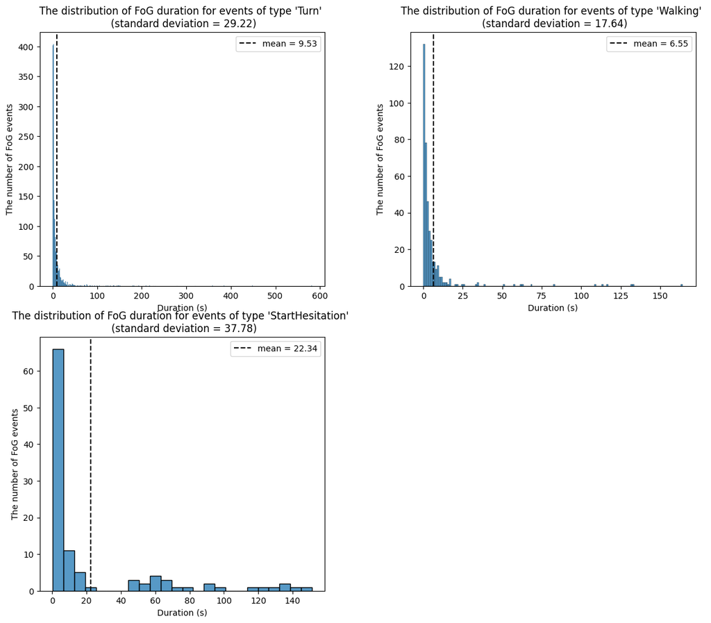

```python
## Plot the distributions of FoG event durations for each Type of event
plt.figure(figsize=(14, 12))
for i, column in enumerate(events_data.dropna().Type.unique(), 1):
    plt.subplot(2, 2, i)
    sns.histplot(events_data[events_data.Type == column].event_duration)
    plt.xlabel(f"Duration (s)")
    plt.ylabel('The number of FoG events')
    plt.axvline(
        events_data[events_data.Type == column].event_duration.mean(), linestyle='dashed',
        label=f'mean = {events_data[events_data.Type == column].event_duration.mean():.2f}',
        color='black')
    plt.legend(loc='best')
    plt.title(f"The distribution of FoG duration for events of type '{column}' \n \
(standard deviation = {events_data[events_data.Type == column].event_duration.std():.2f})")
plt.subplots_adjust(wspace=0.3, hspace=0.2)
plt.show()
```

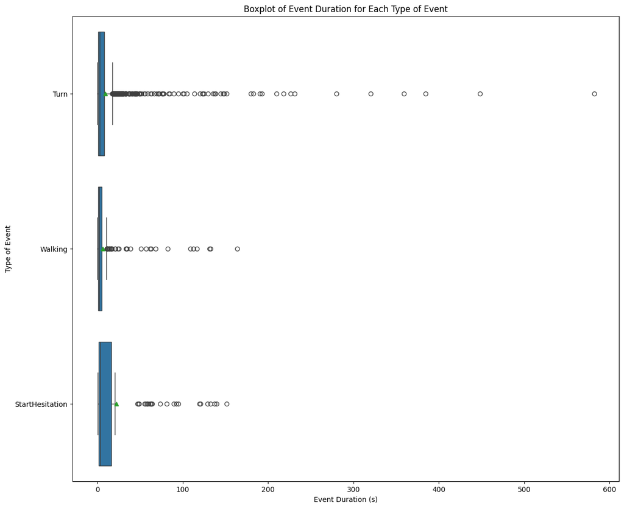

```python
# Create a boxplot for event duration
plt.figure(figsize=(14, 12))
sns.boxplot(x= 'event_duration', y = 'Type', showmeans=True, data = events_data, )
plt.ylabel('Type of Event')
plt.xlabel('Event Duration (s)')
plt.title('Boxplot of Event Duration for Each Type of Event')
plt.show()
```

As we can see, the distributions of FoG event durations for all event Types are highly right-skewed with a large number of outliers, and most FoG episodes lasting less than 30 seconds.

#### Statistics of event durations for each Type

```python
for type_name in events_data.dropna().Type.unique():
    print('Type: ', type_name)
    print(events_data[events_data.Type == type_name].event_duration.agg(
                                    ['min', 'max', 'median', 'mean', 'std']))
    print(f'The value of 95th percentile: \
{events_data[events_data.Type == type_name].event_duration.quantile(0.95):.2f}')
    print('-'* 10 + '\n')
```

```
Type:  Turn
min         0.124000
max       581.980000
median      2.920000
mean        9.532709
std        29.224874
Name: event_duration, dtype: float64
The value of 95th percentile: 29.27
----------

Type:  Walking
min         0.119000
max       164.200000
median      2.140000
mean        6.554683
std        17.639786
Name: event_duration, dtype: float64
The value of 95th percentile: 17.41
----------

Type:  StartHesitation
min         0.240000
max       151.240000
median      3.320000
mean       22.343252
std        37.784590
Name: event_duration, dtype: float64
The value of 95th percentile: 120.58
----------
```

The duration of FoG events of type Walking ranged from 0.119 to 164.20 seconds (mean = 6.55 s, standard deviation = 17.63 s). The 50% of this FoG episodes lasted less than 2.14 seconds, whereas the majority (95%) lasted less than 17.41 seconds.

The duration of FoG events of type StartHesitation ranged from 0.24 to 151.24 seconds (mean = 22.34 s, standard deviation = 37.79 s). The 50% of this FoG episodes lasted less than 3.32 seconds, whereas the majority (95%) lasted less than 120.58 seconds.

## Subjects dataset

```python
subjects_data.head()
```

|  | Subject | Visit | Age | Sex | YearsSinceDx | UPDRSIII_On | UPDRSIII_Off | NFOGQ |
| --- | --- | --- | --- | --- | --- | --- | --- | --- |
| 0 | 00f674 | 2.0 | 63 | M | 27.0 | 43.0 | 49.0 | 24 |
| 1 | 00f674 | 1.0 | 63 | M | 27.0 | 31.0 | 30.0 | 26 |
| 2 | 02bc69 | NaN | 69 | M | 4.0 | 21.0 | NaN | 22 |
| 3 | 040587 | 2.0 | 75 | M | 26.0 | 52.0 | 69.0 | 21 |
| 4 | 040587 | 1.0 | 75 | M | 26.0 | 47.0 | 75.0 | 24 |

```python
# Check for missing values in the subjects_data dataframe
print(subjects_data.isnull().sum())
```

```
Subject          0
Visit           62
Age              0
Sex              0
YearsSinceDx     0
UPDRSIII_On      1
UPDRSIII_Off    41
NFOGQ            0
dtype: int64
```

```python
subjects_data.describe()
```

|  | Visit | Age | YearsSinceDx | UPDRSIII_On | UPDRSIII_Off | NFOGQ |
| --- | --- | --- | --- | --- | --- | --- |
| count | 111.000000 | 173.000000 | 173.000000 | 172.000000 | 132.000000 | 173.000000 |
| mean | 1.369369 | 67.763006 | 10.383931 | 34.273256 | 42.878788 | 17.121387 |
| std | 0.484823 | 7.972075 | 6.289191 | 12.732552 | 12.998550 | 7.575377 |
| min | 1.000000 | 28.000000 | 0.420000 | 5.000000 | 15.000000 | 0.000000 |
| 25% | 1.000000 | 62.000000 | 6.000000 | 25.000000 | 33.000000 | 15.000000 |
| 50% | 1.000000 | 68.000000 | 9.000000 | 35.000000 | 43.000000 | 19.000000 |
| 75% | 2.000000 | 73.000000 | 15.000000 | 42.250000 | 49.250000 | 22.000000 |
| max | 2.000000 | 94.000000 | 30.000000 | 79.000000 | 91.000000 | 29.000000 |

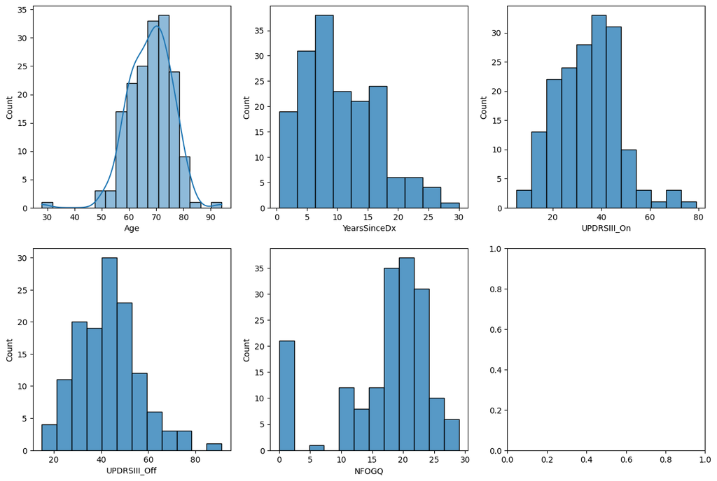

```python
fig, axs = plt.subplots(2, 3, figsize=(15, 10))

sns.histplot(data=subjects_data, x="Age", kde=True, ax=axs[0, 0])
sns.histplot(data=subjects_data, x="YearsSinceDx", ax=axs[0, 1])
sns.histplot(data=subjects_data, x="UPDRSIII_On", ax=axs[0, 2])
sns.histplot(data=subjects_data, x="UPDRSIII_Off", ax=axs[1, 0])
sns.histplot(data=subjects_data, x="NFOGQ", ax=axs[1, 1])

plt.show()
```

```
1.0    70
2.0    41
Name: Visit, dtype: int64
```

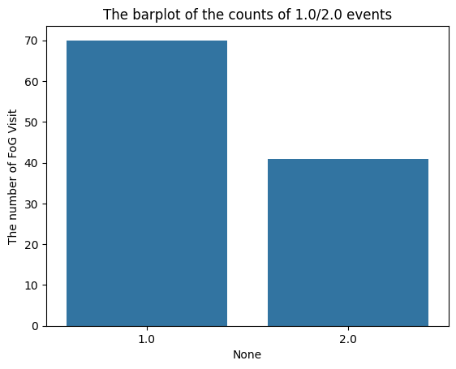

```python
print(subjects_data.Visit.value_counts())
# create a barplot of the counts of kinetic/akinetic events
fig, ax = plt.subplots()
sns.barplot(x=subjects_data.Visit.value_counts().index,
            y=subjects_data.Visit.value_counts())
plt.title('The barplot of the counts of 1.0/2.0 events')
plt.ylabel('The number of FoG Visit')
ax.set_xticklabels(['1.0', '2.0'])
plt.show()
```

```
M    121
F     52
Name: Sex, dtype: int64
```

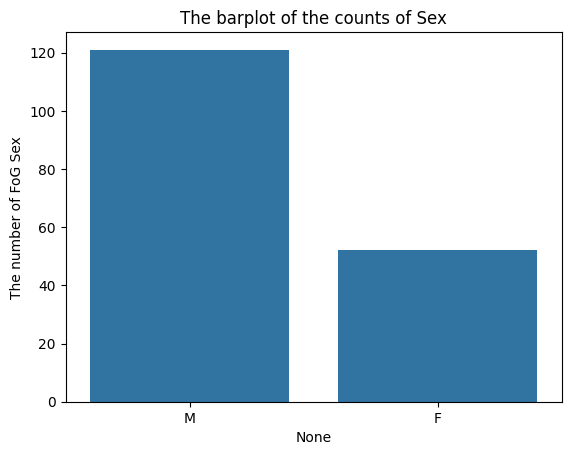

```python
print(subjects_data.Sex.value_counts())
# create a barplot of the counts of kinetic/akinetic events
fig, ax = plt.subplots()
sns.barplot(x=subjects_data.Sex.value_counts().index,
            y=subjects_data.Sex.value_counts())
plt.title('The barplot of the counts of Sex')
plt.ylabel('The number of FoG Sex')
ax.set_xticklabels(['M', 'F'])
plt.show()
```

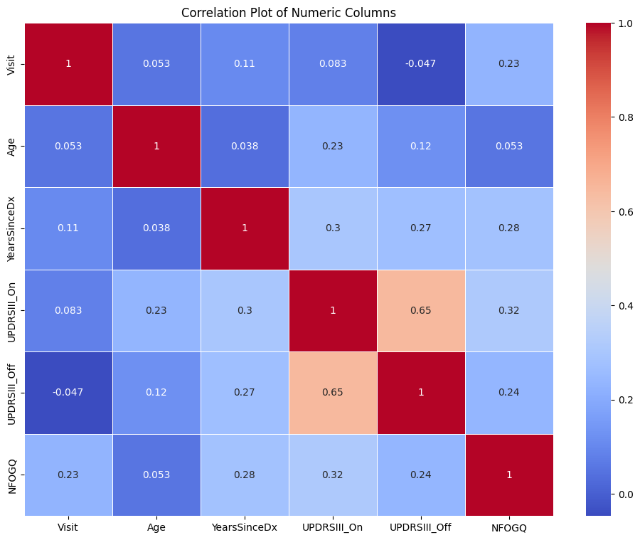

```python
# Get the numeric columns
numeric_columns = subjects_data.select_dtypes(include=['int64', 'float64']).columns

# Create a correlation matrix
correlation_matrix = subjects_data[numeric_columns].corr()

# Generate a heatmap of the correlation matrix
plt.figure(figsize=(12, 9))
sns.heatmap(correlation_matrix, annot=True, linewidths=.5, cmap="coolwarm")
plt.title("Correlation Plot of Numeric Columns")
plt.show()
```

Let's concatenate thetdcsfog metadata with the defog metadata, and then merge the result with the subjects dataset for further analysis.

## metadata

```python
tdcsfog_metadata.head()
```

|  | Id | Subject | Visit | Test | Medication |
| --- | --- | --- | --- | --- | --- |
| 0 | 003f117e14 | 4dc2f8 | 3 | 2 | on |
| 1 | 009ee11563 | f62eec | 4 | 2 | on |
| 2 | 011322847a | 231c3b | 2 | 2 | on |
| 3 | 01d0fe7266 | 231c3b | 2 | 1 | off |
| 4 | 024418ba39 | fa8764 | 19 | 3 | on |

```python
defog_metadata.head()
```

|  | Id | Subject | Visit | Medication |
| --- | --- | --- | --- | --- |
| 0 | 02ab235146 | e1f62e | 2 | on |
| 1 | 02ea782681 | ae2d35 | 2 | on |
| 2 | 06414383cf | 8c1f5e | 2 | off |
| 3 | 092b4c1819 | 2874c5 | 1 | off |
| 4 | 0a900ed8a2 | 0e3d49 | 2 | on |

```python
tdcsfog_metadata['dataset'] = 'tdcsfog'
defog_metadata['dataset'] = 'defog'

full_metadata = pd.concat([tdcsfog_metadata, defog_metadata])

all_metadata_df = events_data[['Id', 'Type', 'Kinetic', 'event_duration']].merge(full_metadata, on='Id').merge(subjects_data.drop('Visit', axis=1), on='Subject')
all_metadata_df.head()
```

|  | Id | Type | Kinetic | event_duration | Subject | Visit | Test | Medication | dataset | Age | Sex | YearsSinceDx | UPDRSIII_On | UPDRSIII_Off | NFOGQ |
| --- | --- | --- | --- | --- | --- | --- | --- | --- | --- | --- | --- | --- | --- | --- | --- |
| 0 | 003f117e14 | Turn | 1.0 | 6.15998 | 4dc2f8 | 3 | 2.0 | on | tdcsfog | 68 | F | 9.0 | 17.0 | 15.0 | 15 |
| 1 | 2ca9bd3533 | Turn | 1.0 | 1.96000 | 4dc2f8 | 2 | 3.0 | on | tdcsfog | 68 | F | 9.0 | 17.0 | 15.0 | 15 |
| 2 | 2ca9bd3533 | Walking | 1.0 | 0.96000 | 4dc2f8 | 2 | 3.0 | on | tdcsfog | 68 | F | 9.0 | 17.0 | 15.0 | 15 |
| 3 | 2ca9bd3533 | Walking | 1.0 | 0.68000 | 4dc2f8 | 2 | 3.0 | on | tdcsfog | 68 | F | 9.0 | 17.0 | 15.0 | 15 |
| 4 | 64e69dbfab | Turn | 1.0 | 3.36000 | 4dc2f8 | 2 | 1.0 | on | tdcsfog | 68 | F | 9.0 | 17.0 | 15.0 | 15 |

```python
all_metadata_df.Sex = np.where(all_metadata_df.Sex == 'F', 0, 1)
all_metadata_df.Medication = np.where(all_metadata_df.Medication == 'off', 0, 1)
```

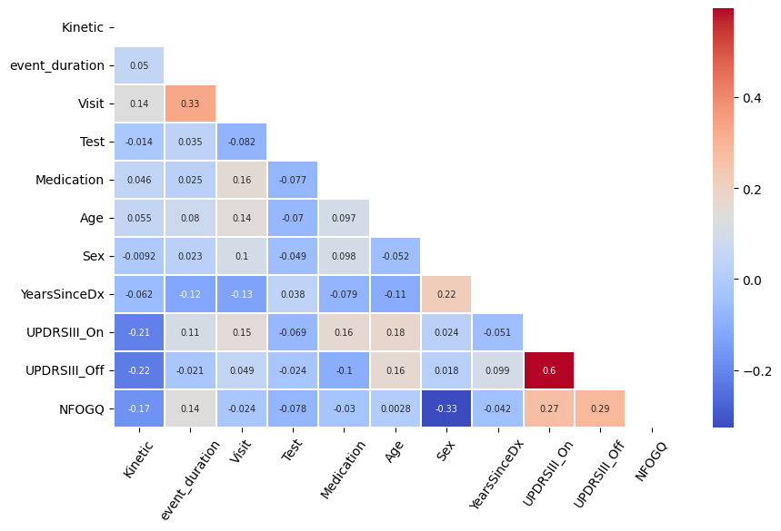

```python
plt.figure(figsize=(10, 6))
mask = np.triu(np.ones_like(all_metadata_df.corr(), dtype=bool))
sns.heatmap(all_metadata_df.corr(), mask=mask, annot=True, cmap='coolwarm',
                linewidths=0.2, annot_kws={"size": 7}, rasterized=True)
plt.xticks(rotation=55)
plt.show()
```

## The train Datasets exploring

train/ Folder containing the data series in the training set within three subfolders: tdcsfog/, defog/, and notype/.

Series in the notype folder are from the defog dataset but lack event-type annotations. The fields present in these series vary by folder.

Time An integer timestep. Series from the tdcsfog dataset are recorded at 128Hz (128 timesteps per second), while series from the defog and daily series are recorded at 100Hz (100 timesteps per second).

AccV, AccML, and AccAP Acceleration in units of g, from a lower-back sensor on three axes: V - vertical, ML - mediolateral, AP - anteroposterior.

StartHesitation, Turn, Walking Indicator variables for the occurrence of each of the event types.

Event Indicator variable for the occurrence of any FOG-type event. Present only in the notype series, which lack type-level annotations.

Valid There were cases during the video annotation that were hard for the annotator to decide if there was an Akinetic (i.e., essentially no movement) FoG or the subject stopped voluntarily. Only event annotations where the series is marked true should be considered as unambiguous.

Task Series were only annotated where this value is true. Portions marked false should be considered unannotated.

```python
# Read files of the tdcsfog metadata (the total number of files is 833)
tdcsfog_files = [f'{data_dir}train/tdcsfog/{id}.csv' for id in \
                                         tdcsfog_metadata.Id.to_list()]

tdcsfog_data = pd.concat([pd.read_csv(file) for file in tdcsfog_files])
```

```python
tdcsfog_data.head()
```

|  | Time | AccV | AccML | AccAP | StartHesitation | Turn | Walking |
| --- | --- | --- | --- | --- | --- | --- | --- |
| 0 | 0 | -9.533939 | 0.566322 | -1.413525 | 0 | 0 | 0 |
| 1 | 1 | -9.536140 | 0.564137 | -1.440621 | 0 | 0 | 0 |
| 2 | 2 | -9.529345 | 0.561765 | -1.429332 | 0 | 0 | 0 |
| 3 | 3 | -9.531239 | 0.564227 | -1.415490 | 0 | 0 | 0 |
| 4 | 4 | -9.540825 | 0.561854 | -1.429471 | 0 | 0 | 0 |

```python
print(tdcsfog_data.isnull().sum())
```

```
Time               0
AccV               0
AccML              0
AccAP              0
StartHesitation    0
Turn               0
Walking            0
dtype: int64
```

```python
tdcsfog_data.describe()
```

|  | Time | AccV | AccML | AccAP | StartHesitation | Turn | Walking |
| --- | --- | --- | --- | --- | --- | --- | --- |
| count | 7.062672e+06 | 7.062672e+06 | 7.062672e+06 | 7.062672e+06 | 7.062672e+06 | 7.062672e+06 | 7.062672e+06 |
| mean | 9.289467e+03 | -9.306317e+00 | -2.012513e-01 | 1.808524e+00 | 4.315506e-02 | 2.376979e-01 | 2.942767e-02 |
| std | 1.399893e+04 | 1.080174e+00 | 1.269525e+00 | 2.285849e+00 | 2.032061e-01 | 4.256731e-01 | 1.690020e-01 |
| min | 0.000000e+00 | -3.552112e+01 | -2.616440e+01 | -4.782964e+01 | 0.000000e+00 | 0.000000e+00 | 0.000000e+00 |
| 25% | 2.119000e+03 | -9.762402e+00 | -9.295446e-01 | 5.672254e-01 | 0.000000e+00 | 0.000000e+00 | 0.000000e+00 |
| 50% | 4.310000e+03 | -9.363524e+00 | -1.722245e-01 | 1.987101e+00 | 0.000000e+00 | 0.000000e+00 | 0.000000e+00 |
| 75% | 8.433000e+03 | -8.776814e+00 | 5.752114e-01 | 3.449026e+00 | 0.000000e+00 | 0.000000e+00 | 0.000000e+00 |
| max | 9.707600e+04 | 2.090695e+01 | 2.748472e+01 | 3.033769e+01 | 1.000000e+00 | 1.000000e+00 | 1.000000e+00 |

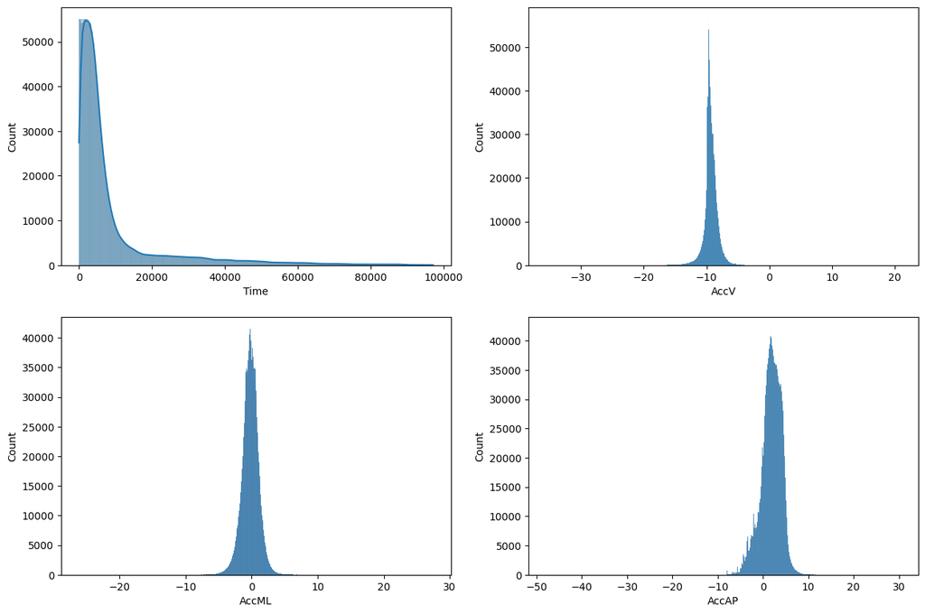

```python
fig, axs = plt.subplots(2, 2, figsize=(15, 10))

sns.histplot(data=tdcsfog_data, x="Time", kde=True, ax=axs[0, 0])
sns.histplot(data=tdcsfog_data, x="AccV", ax=axs[0, 1])
sns.histplot(data=tdcsfog_data, x="AccML", ax=axs[1, 0])
sns.histplot(data=tdcsfog_data, x="AccAP", ax=axs[1, 1])

plt.show()
```

```
0    6757882
1     304790
Name: StartHesitation, dtype: int64
```

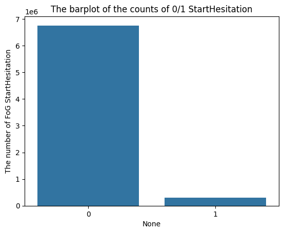

```python
print(tdcsfog_data.StartHesitation.value_counts())
fig, ax = plt.subplots()
sns.barplot(x=tdcsfog_data.StartHesitation.value_counts().index,
            y=tdcsfog_data.StartHesitation.value_counts())
plt.title('The barplot of the counts of 0/1 StartHesitation')
plt.ylabel('The number of FoG StartHesitation')
ax.set_xticklabels(['0', '1'])
plt.show()
```

```
0    5383890
1    1678782
Name: Turn, dtype: int64
```

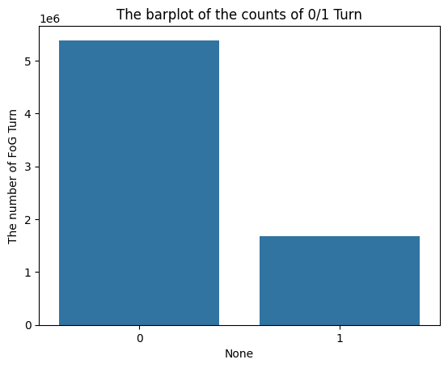

```python
print(tdcsfog_data.Turn.value_counts())
fig, ax = plt.subplots()
sns.barplot(x=tdcsfog_data.Turn.value_counts().index,
            y=tdcsfog_data.Turn.value_counts())
plt.title('The barplot of the counts of 0/1 Turn')
plt.ylabel('The number of FoG Turn')
ax.set_xticklabels(['0', '1'])
plt.show()
```

```
0    6854834
1     207838
Name: Walking, dtype: int64
```

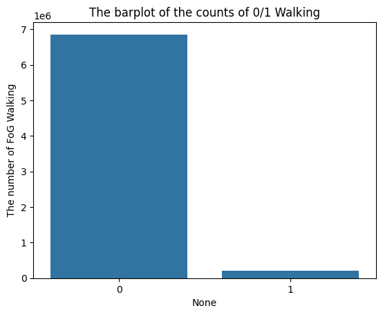

```python
print(tdcsfog_data.Walking.value_counts())
fig, ax = plt.subplots()
sns.barplot(x=tdcsfog_data.Walking.value_counts().index,
            y=tdcsfog_data.Walking.value_counts())
plt.title('The barplot of the counts of 0/1 Walking')
plt.ylabel('The number of FoG Walking')
ax.set_xticklabels(['0', '1'])
plt.show()
```

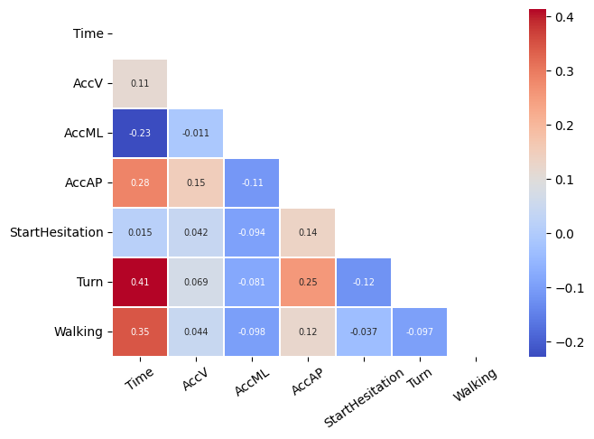

```python
mask = np.triu(np.ones_like(tdcsfog_data.corr(), dtype=bool))
fig, ax = plt.subplots(figsize=(7, 5))
sns.heatmap(tdcsfog_data.corr(), mask=mask, annot=True, cmap='coolwarm',
                linewidths=0.2, annot_kws={"size": 7}, rasterized=True)
plt.xticks(rotation=35)
plt.show()
```

From dataset report and correlation matrix, it can be concluded that:

#### DeFog Dataset

The DeFOG (defog) dataset comprises data series collected in the subject's home, as subjects completed a FOG-provoking protocol.

As we know from the data descriptions, the series in the notype folder are from the DeFOG dataset but lack event-type annotations. Let's create a list of indices that correspond to the notype series IDs. Using this list, we can separate the defog_metadata set into two metadata sets: one for notype and one for defog series.

```python
# Creating a list of indices that correspond to the notype series IDs in the defog_metadata
notype_idx = [0, 4, 13, 15, 17, 19, 20, 22, 25, 27, 30, 31, 32, 34, 36, 40, 42,
              53, 54, 55, 58, 60, 62, 66, 67, 73, 74, 76, 79, 83, 84, 88, 89, 94,
              96, 97, 98, 101, 102, 105, 113, 114, 115, 121, 124, 126]

# Separating the defog_metadata
defog_metadata_only = defog_metadata[~defog_metadata.index.isin(notype_idx)].copy()
notype_metadata = defog_metadata[defog_metadata.index.isin(notype_idx)].copy()
```

```python
# Read one file of the defog metadata (the total number of files is 91)
defog_files = [f'{data_dir}train/defog/{id}.csv' for id in \
                               defog_metadata_only.Id.to_list()]

defog_data = pd.concat([pd.read_csv(file) for file in defog_files])
```

```python
defog_data.head()
```

|  | Time | AccV | AccML | AccAP | StartHesitation | Turn | Walking | Valid | Task |
| --- | --- | --- | --- | --- | --- | --- | --- | --- | --- |
| 0 | 0 | -1.0 | 0.044129 | -0.25 | 0 | 0 | 0 | False | False |
| 1 | 1 | -1.0 | 0.034431 | -0.25 | 0 | 0 | 0 | False | False |
| 2 | 2 | -1.0 | 0.031250 | -0.25 | 0 | 0 | 0 | False | False |
| 3 | 3 | -1.0 | 0.031250 | -0.25 | 0 | 0 | 0 | False | False |
| 4 | 4 | -1.0 | 0.031250 | -0.25 | 0 | 0 | 0 | False | False |

defog has both valid datas and invalid data, we will only keep the valid data.

```python
defog_data_valid = defog_data.loc[(defog_data.Valid == True) & (defog_data.Task == True)]

defog_data_valid = defog_data_valid.drop(columns=['Valid', 'Task'])

defog_data_valid.head()
```

|  | Time | AccV | AccML | AccAP | StartHesitation | Turn | Walking |
| --- | --- | --- | --- | --- | --- | --- | --- |
| 1000 | 1000 | -0.970018 | 0.061626 | -0.265625 | 0 | 0 | 0 |
| 1001 | 1001 | -0.984375 | 0.044497 | -0.265625 | 0 | 0 | 0 |
| 1002 | 1002 | -0.984375 | 0.029016 | -0.265625 | 0 | 0 | 0 |
| 1003 | 1003 | -0.984375 | 0.015625 | -0.265625 | 0 | 0 | 0 |
| 1004 | 1004 | -0.984670 | 0.015330 | -0.265625 | 0 | 0 | 0 |

```python
print(defog_data_valid.isnull().sum())
```

```
Time               0
AccV               0
AccML              0
AccAP              0
StartHesitation    0
Turn               0
Walking            0
dtype: int64
```

```python
defog_data_valid.shape
```

```
(4090530, 7)
```

```python
defog_data_valid.describe()
```

|  | Time | AccV | AccML | AccAP | StartHesitation | Turn | Walking |
| --- | --- | --- | --- | --- | --- | --- | --- |
| count | 4.090530e+06 | 4.090530e+06 | 4.090530e+06 | 4.090530e+06 | 4.090530e+06 | 4.090530e+06 | 4.090530e+06 |
| mean | 9.112536e+04 | -9.349461e-01 | -1.229101e-03 | -2.257802e-01 | 1.222335e-04 | 1.434604e-01 | 2.408441e-02 |
| std | 7.025916e+04 | 1.072241e-01 | 1.401177e-01 | 2.444683e-01 | 1.105525e-02 | 3.505418e-01 | 1.533113e-01 |
| min | 1.000000e+03 | -6.024701e+00 | -2.115008e+00 | -5.118650e+00 | 0.000000e+00 | 0.000000e+00 | 0.000000e+00 |
| 25% | 3.552900e+04 | -9.852707e-01 | -8.466136e-02 | -3.634808e-01 | 0.000000e+00 | 0.000000e+00 | 0.000000e+00 |
| 50% | 7.682200e+04 | -9.392389e-01 | 0.000000e+00 | -2.500000e-01 | 0.000000e+00 | 0.000000e+00 | 0.000000e+00 |
| 75% | 1.295620e+05 | -8.869629e-01 | 9.248055e-02 | -1.132356e-01 | 0.000000e+00 | 0.000000e+00 | 0.000000e+00 |
| max | 4.143870e+05 | 4.458365e+00 | 4.524038e+00 | 4.388132e+00 | 1.000000e+00 | 1.000000e+00 | 1.000000e+00 |

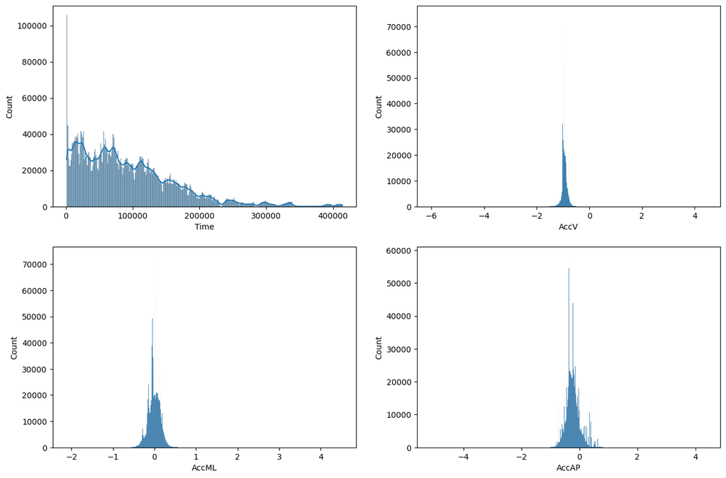

```python
fig, axs = plt.subplots(2, 2, figsize=(15, 10))

sns.histplot(data=defog_data_valid, x="Time", kde=True, ax=axs[0, 0])
sns.histplot(data=defog_data_valid, x="AccV", ax=axs[0, 1])
sns.histplot(data=defog_data_valid, x="AccML", ax=axs[1, 0])
sns.histplot(data=defog_data_valid, x="AccAP", ax=axs[1, 1])

plt.show()
```

```
0    4090030
1        500
Name: StartHesitation, dtype: int64
```

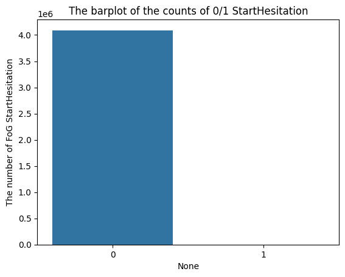

```python
print(defog_data_valid.StartHesitation.value_counts())
fig, ax = plt.subplots()
sns.barplot(x=defog_data_valid.StartHesitation.value_counts().index,
            y=defog_data_valid.StartHesitation.value_counts())
plt.title('The barplot of the counts of 0/1 StartHesitation')
plt.ylabel('The number of FoG StartHesitation')
ax.set_xticklabels(['0', '1'])
plt.show()
```

```
0    3503701
1     586829
Name: Turn, dtype: int64
```

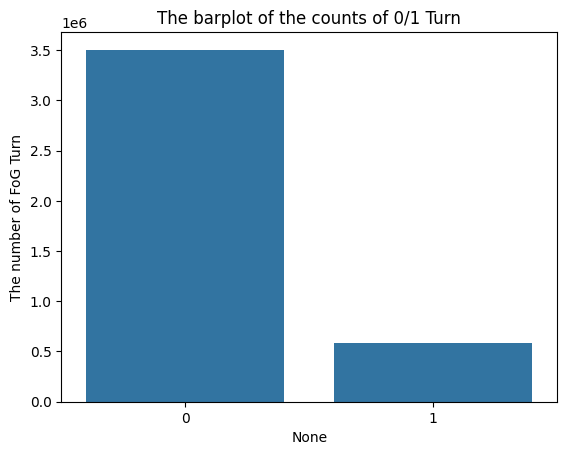

```python
print(defog_data_valid.Turn.value_counts())
fig, ax = plt.subplots()
sns.barplot(x=defog_data_valid.Turn.value_counts().index,
            y=defog_data_valid.Turn.value_counts())
plt.title('The barplot of the counts of 0/1 Turn')
plt.ylabel('The number of FoG Turn')
ax.set_xticklabels(['0', '1'])
plt.show()
```

```
0    3992012
1      98518
Name: Walking, dtype: int64
```

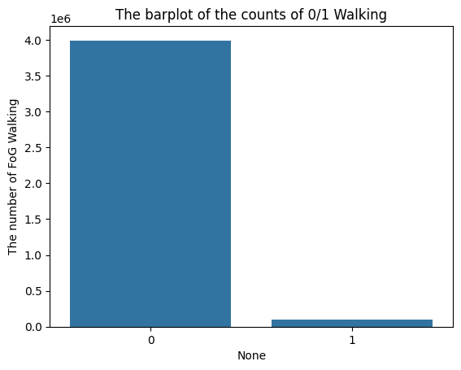

```python
print(defog_data_valid.Walking.value_counts())
fig, ax = plt.subplots()
sns.barplot(x=defog_data_valid.Walking.value_counts().index,
            y=defog_data_valid.Walking.value_counts())
plt.title('The barplot of the counts of 0/1 Walking')
plt.ylabel('The number of FoG Walking')
ax.set_xticklabels(['0', '1'])
plt.show()
```

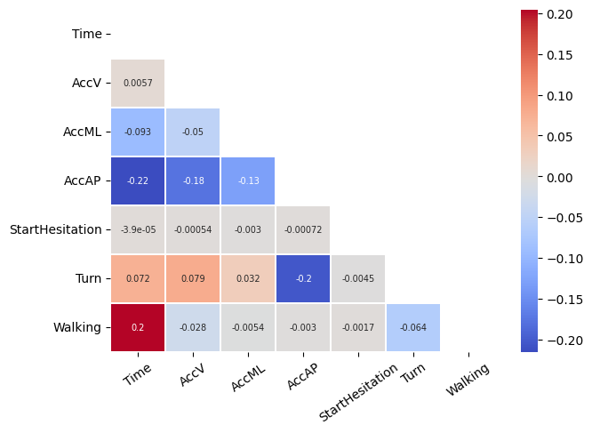

```python
mask = np.triu(np.ones_like(defog_data_valid.corr(), dtype=bool))
fig, ax = plt.subplots(figsize=(7, 5))
sns.heatmap(defog_data_valid.corr(), mask=mask, annot=True, cmap='coolwarm',
                linewidths=0.2, annot_kws={"size": 7}, rasterized=True)
plt.xticks(rotation=35)
plt.show()
```

## Connect tdcsfog and defog dataset with Subject

### tdcsfog dataset

```python
# list of all tdcsfog csv file path
tdcs_file_path = glob.glob(os.path.join(data_dir, 'train', 'tdcsfog', '*.csv'), recursive=True)
```

```python
# Initialize a DataFrame to combine data from multiple CSV files.
df_tdcs = pd.DataFrame()

# load tdcsfog time series in combination with metadata.
for fp in tqdm.tqdm(tdcs_file_path):

    # load data into a variable 'tmp'.
    tmp = pd.read_csv(fp)

    # get file Id from csv file name.
    file_id = os.path.basename(fp).replace(".csv", "")

    # get subject Id.
    subject = tdcsfog_metadata.loc[tdcsfog_metadata['Id'] == file_id, 'Subject'].iloc[0]

    # add metadata.
    tmp['Medication'] = tdcsfog_metadata.loc[tdcsfog_metadata['Id'] == file_id, 'Medication'].iloc[0]
    tmp['Age'] = subjects_data.loc[subjects_data['Subject'] == subject, 'Age'].iloc[0]
    tmp['Sex'] = subjects_data.loc[subjects_data['Subject'] == subject, 'Sex'].iloc[0]
    tmp['YearsSinceDx'] = subjects_data.loc[subjects_data['Subject'] == subject, 'YearsSinceDx'].iloc[0]
    tmp['NFOGQ'] =subjects_data.loc[subjects_data['Subject'] == subject, 'NFOGQ'].iloc[0]

    # concat the data
    df_tdcs = pd.concat([df_tdcs, tmp]).reset_index(drop=True)
```

```python
df_tdcs.head()
```

|  | Time | AccV | AccML | AccAP | StartHesitation | Turn | Walking | Medication | Age | Sex | YearsSinceDx | NFOGQ |
| --- | --- | --- | --- | --- | --- | --- | --- | --- | --- | --- | --- | --- |
| 0 | 0 | -9.671054 | -0.097687 | -2.193385 | 0 | 0 | 0 | on | 69 | M | 4.0 | 22 |
| 1 | 1 | -9.674142 | -0.094618 | -2.192642 | 0 | 0 | 0 | on | 69 | M | 4.0 | 22 |
| 2 | 2 | -9.675552 | -0.092203 | -2.188145 | 0 | 0 | 0 | on | 69 | M | 4.0 | 22 |
| 3 | 3 | -9.684805 | -0.092936 | -2.191913 | 0 | 0 | 0 | on | 69 | M | 4.0 | 22 |
| 4 | 4 | -9.678051 | -0.093119 | -2.202334 | 0 | 0 | 0 | on | 69 | M | 4.0 | 22 |

```python
df_tdcs.shape
```

```
(7062672, 12)
```

```python
# encode string columns into 0/1 format
df_tdcs['Medication'] = np.where(df_tdcs['Medication']=='on', 1, 0)
df_tdcs['Sex'] = np.where(df_tdcs['Sex']=='M', 1, 0)
df_tdcs.head()
```

|  | Time | AccV | AccML | AccAP | StartHesitation | Turn | Walking | Medication | Age | Sex | YearsSinceDx | NFOGQ |
| --- | --- | --- | --- | --- | --- | --- | --- | --- | --- | --- | --- | --- |
| 0 | 0 | -9.671054 | -0.097687 | -2.193385 | 0 | 0 | 0 | 1 | 69 | 1 | 4.0 | 22 |
| 1 | 1 | -9.674142 | -0.094618 | -2.192642 | 0 | 0 | 0 | 1 | 69 | 1 | 4.0 | 22 |
| 2 | 2 | -9.675552 | -0.092203 | -2.188145 | 0 | 0 | 0 | 1 | 69 | 1 | 4.0 | 22 |
| 3 | 3 | -9.684805 | -0.092936 | -2.191913 | 0 | 0 | 0 | 1 | 69 | 1 | 4.0 | 22 |
| 4 | 4 | -9.678051 | -0.093119 | -2.202334 | 0 | 0 | 0 | 1 | 69 | 1 | 4.0 | 22 |

### defog dataset

```python
# list of all tdcsfog csv file path
defog_file_path = glob.glob(os.path.join(data_dir, 'train', 'defog', '*.csv'), recursive=True)
```

```python
# Initialize a DataFrame to combine data from multiple CSV files.
df_defog = pd.DataFrame()

for fp in tqdm.tqdm(defog_file_path):
    # load data into a variable 'tmp'.
    tmp = pd.read_csv(fp)

    # get file Id from csv file name.
    file_id = os.path.basename(fp).replace(".csv", "")

    # get subject Id.
    subject = defog_metadata.loc[defog_metadata['Id'] == file_id, 'Subject'].iloc[0]

    # add metadata.
    tmp['Medication'] = defog_metadata.loc[defog_metadata['Id'] == file_id, 'Medication'].iloc[0]
    tmp['Age'] = subjects_data.loc[subjects_data['Subject'] == subject, 'Age'].iloc[0]
    tmp['Sex'] = subjects_data.loc[subjects_data['Subject'] == subject, 'Sex'].iloc[0]
    tmp['YearsSinceDx'] = subjects_data.loc[subjects_data['Subject'] == subject, 'YearsSinceDx'].iloc[0]
    tmp['NFOGQ'] =subjects_data.loc[subjects_data['Subject'] == subject, 'NFOGQ'].iloc[0]

    # extract data from the time period where Valid and Task are both True.
    tmp = tmp[(tmp['Valid'] == True) & (tmp['Task']==True)]
    tmp = tmp.drop(['Valid', 'Task'], axis=1)

    # concat the data
    df_defog = pd.concat([df_defog, tmp]).reset_index(drop=True)
```

```python
df_defog.head()
```

|  | Time | AccV | AccML | AccAP | StartHesitation | Turn | Walking | Medication | Age | Sex | YearsSinceDx | NFOGQ |
| --- | --- | --- | --- | --- | --- | --- | --- | --- | --- | --- | --- | --- |
| 0 | 1000 | -0.953630 | 0.023207 | -0.397874 | 0 | 0 | 0 | off | 61 | F | 7.0 | 22 |
| 1 | 1001 | -0.964072 | 0.024408 | -0.398529 | 0 | 0 | 0 | off | 61 | F | 7.0 | 22 |
| 2 | 1002 | -0.968473 | 0.028320 | -0.387927 | 0 | 0 | 0 | off | 61 | F | 7.0 | 22 |
| 3 | 1003 | -0.965339 | 0.028354 | -0.371597 | 0 | 0 | 0 | off | 61 | F | 7.0 | 22 |
| 4 | 1004 | -0.954387 | 0.029757 | -0.361989 | 0 | 0 | 0 | off | 61 | F | 7.0 | 22 |

```python
df_defog.shape
```

```
(4090530, 12)
```

```python
# encode string columns into 0/1 format
df_defog['Medication'] = np.where(df_defog['Medication']=='on', 1, 0)
df_defog['Sex'] = np.where(df_defog['Sex']=='M', 1, 0)
df_defog.head()
```

|  | Time | AccV | AccML | AccAP | StartHesitation | Turn | Walking | Medication | Age | Sex | YearsSinceDx | NFOGQ |
| --- | --- | --- | --- | --- | --- | --- | --- | --- | --- | --- | --- | --- |
| 0 | 1000 | -0.953630 | 0.023207 | -0.397874 | 0 | 0 | 0 | 0 | 61 | 0 | 7.0 | 22 |
| 1 | 1001 | -0.964072 | 0.024408 | -0.398529 | 0 | 0 | 0 | 0 | 61 | 0 | 7.0 | 22 |
| 2 | 1002 | -0.968473 | 0.028320 | -0.387927 | 0 | 0 | 0 | 0 | 61 | 0 | 7.0 | 22 |
| 3 | 1003 | -0.965339 | 0.028354 | -0.371597 | 0 | 0 | 0 | 0 | 61 | 0 | 7.0 | 22 |
| 4 | 1004 | -0.954387 | 0.029757 | -0.361989 | 0 | 0 | 0 | 0 | 61 | 0 | 7.0 | 22 |

```python
#df_tdcs.to_csv('/content/drive/MyDrive/DSC672/data/full_tdcsfog.csv',index=False)
```

```python
#df_defog.to_csv('/content/drive/MyDrive/DSC672/data/full_defog.csv',index=False)
```

```python
# prompt: Save ipynb to html

from google.colab import output

output.clear()

!jupyter nbconvert --to html /content/drive/MyDrive/DSC672/code/EDA.ipynb
```

```
[NbConvertApp] Converting notebook /content/drive/MyDrive/DSC672/code/EDA.ipynb to html
[NbConvertApp] Writing 1704202 bytes to /content/drive/MyDrive/DSC672/code/EDA.html
```